# FastAPI

## Some notes first

- you should really stop using pip and start using uv (uv is a pip alternative, please go and watch: https://youtu.be/AMdG7IjgSPM?si=2NCbkP6E1kPtUVfB)
- Once you have uv isntalled and working, you can hit the following commands easily:
  - uv init (init command initializes a python/uv project in the folder)
  - uv add 'fastapi[standard]' (this is the same as pip install fastapi)

## Some basics before starting

- The goal we are trying to achieve here is simple. We have to setup a url/endpoint that the frontend (javascript or typescript) can hit with fetch or axios to make requests, like a GET or POST or anything like that
- Here is some simple code for the frontend, this is kinda like that code that the frontend engineer will be writing:

```python
async function getData(): Promise<void> {
    try {
        const response = await fetch("http://127.0.0.1:8000/getdata")
        if (!response.ok) {
            return
            // throw some error
        }
        const data = await response.json()
        console.log(data)
        // now here we will do something with the data, probably use a setState function to set it in a state
    } catch (e) {
        console.log(`yo we got some error ma dawg: ${e}`)
    }
}
```

- now, where does that http//:localhost:8000/getdata come from? Well, we basically create that endpoint using fastapi

## **Setup app and simple endpoint**

```python
# step 1: create a fastapi application with the FastAPI constructor
from fastapi import FastAPI

app = FastAPI()
```

```python
# step 2: we setup an endpoint using decorators, you don't need to learn what decorators are or how they work, just use this code simply:

# this creates the default route, if you visit localhost:8000 now, you will have the following dictionary returning
@app.get("/")
def get_data():
    return {"hello there": "yo yo mate, whats popping. this is the default route"}

@app.get("/getdata")
def getdata():
    return {
        "id": 12705,
        "childName": "Junaid",
        "childHeartRate": 467
    }
```

- lets try to breakdown step 2 further:
  - 1. we use @app.get or @app.post or whatever decorator to make a new endpoint
  - 2. we then define a function under the decorator that does something (returns some data, receive some data, etc etc)
  - 3. Its convention to return a dictionary from these endpoint functions because python dictionaries map nicely to JSON and also typescript types on the frontend. Later we will learn about pydantic data models which map even more perfectly to the frontend typescript types
- lets see the output

#### Note:

- you run fastapi code in .py files, not .ipynb files. So make sure to make a .py file and write the code in that.
- you can hit uv run fastapi dev to run the code.
- once running, you will see something like this in the terminal:

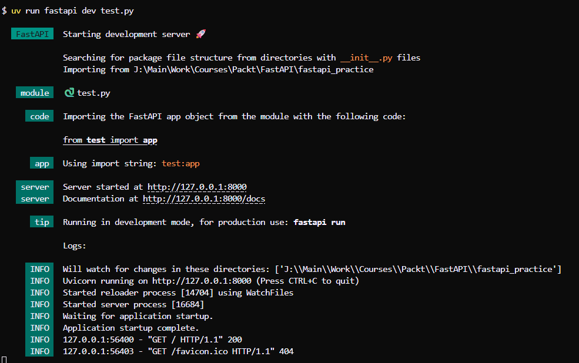

- visit http://127.0.0.1:8000 and you will see:

[figure not shown]

- we can see the dictionary we returned.
- visit the secondd endpoint we made at http://127.0.0.1:8000/getdata and we will see:

[figure not shown]

- That is the core and simplest concept, we make endpoints, we send or receive data from those endpoints or do many other things as well.
- now lets cover someother basics:
  - how to receive data on an endpoint
  - how to make parameterized endpoints
  - how to view documentation

## **Viewing and testing our endpoint**

- you can visit http://127.0.0.1:8000/docs and you will see:

[figure not shown]

- This is an auto generated documentation page where one can view and test out the api endpoint we just created. The frontend engineer should first use this and test it out and see if everything works well, then they should write the frontend code to hit the endpoints.

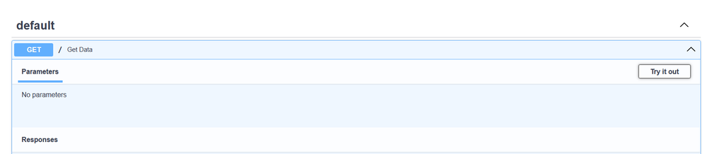

- we can press the try it out button to test the endpoint and see output and manipulate parameters etc

## **create a parameterized route**

- lets say the frontend wants to view the data of a specific child

```python
# some dummy data
db = {
    12701: {
        "weight": 3.5,
        "content": "furniture",
        "status": "in transit"
    },
    12702: {
        "weight": 1.2,
        "content": "books",
        "status": "delivered"
    },
    12703: {
        "weight": 7.8,
        "content": "electronics",
        "status": "pending"
    },
    12704: {
        "weight": 2.0,
        "content": "clothes",
        "status": "in transit"
    },
    12705: {
        "weight": 5.5,
        "content": "appliances",
        "status": "shipped"
    },
    12706: {
        "weight": 0.9,
        "content": "toys",
        "status": "delivered"
    }
}
```

```python
from fastapi import HTTPException, status
@app.get("/getdata/{id}")
def getdata_by_id(id: int):
    # some code to fetch that exact child by id from the database. but since our "db" is just the dict above, we can do this:
    if id not in db:
        raise HTTPException(
            status_code=status.HTTP_404_NOT_FOUND,
            detail="Given id does not exist"
        )
    return db[id]
```

- Lets review:
  - 1. we use {} in the decorator to create a dynamic endpoint
  - 2. we receive that dynamic part of the endpoint into our function by having parameter in the function with the same name.
  - 3. the : int is type annotation that enforces the type of data
  - 4. we return a proper http error if the id does not exist
  - 5. we return the data if everything goes fine
- we can now visit http://127.0.0.1:8000/docs again after saving the code and we will see:

[figure not shown]

- there is a third new get endpoint at /getdata/{id}. we can of course test it out in the documentation with the try it out button. or we could just visit it directly:

[figure not shown]

- if we visit an id that does not exist. it returns a proper error:

[figure not shown]

## **Query params**

- The frontend primarily gives us data in 2 ways:
  - route params: [http://127.0.0.1:8000/getdata/{id}](http://127.0.0.1:8000/getdata/%7Bid%7D) (what we did above with id)
  - query params: what we are going to do now

```python
# no dynamic endpoinst needed for query params

@app.get("/getdata/anything")
def getdata_with_query_params(sort_by: str):
    if sort_by not in ("asc", "dsc"):
        raise HTTPException(
            status_code=400,
            detail="invalid sort order option selected"
        )
    return sort_by
```

- Lets break this down:
  - 1. note how the url in the decorator is not special, it is just a simple static route
  - 2. but the function does have a parameter and therefore we can pass it arguments
  - 3. if you visit getdata/anything and do not give any query params, you will get this:

[figure not shown]

- 4. lets hit it again but this time. lets give it a query param:

[figure not shown]

- our function was able to grab the query param from the url and then we used it in the function
- **note**: declare static route functions above dynamic route ones. if you have the following two functions:
  - getdata/anything
  - getdata/{id}
- the second one is dynamic, if you declare it above the getdata/anything function in the .py file, your getdata/anything will also get intercepted by getdata/{id} since {id} is dynamic and can accept anything.

## **Pydantic Data Modal**

- we saw previously that we set the type of data we wanna receive using type annotation (eg id: int) and then if we give some other data type then it gives an error:

[figure not shown]

- but the frontend might need to send us data of an entire form. for example we have a form on our frontend and it has several fields like device_id, temparature, humidity and status etc. What do we do in that case? We will use pydantic data modals. These are like the models from flutter or types from typescript

```python
from pydantic import BaseModel, Field
from typing import Literal

class SensorReading(BaseModel):
    device_id: str = Field(min_length=3)
    temperature_c: float
    humidity: float
    status: Literal["ok", "warn", "error"]

@app.post("/readings")
def create_reading(payload: SensorReading):
    # the data validation will be done automatically now because of the pydantic modal but we can do further validation with if cases and HTTPException:
    if payload.temperature_c < -50 or payload.temperature_c > 150:
        raise HTTPException(status_code=400, detail="temperature out of range")
    return {"stored": True, "data": payload}
```

- as you can see, a pydantic modal is just a simple python class that inherits the BaseModel class from pydantic library and then we simply provide the fields we have in that class.
- we get other utilities from pydantic too like the Field method that can be used to specify the minimum length etc and put validations on the fields easily.
- after defining the pydantic modal, we assign that class to our parameter in the function so now our function accepts that entire pydantic data modal from the frontend. The frontend will send this to us kinda like this:

```python
// a typscript type
type SensorReading = {
  device_id: string;
  temperature_c: number;
  humidity: number;
  status: "ok" | "warn" | "error";
};


async function sendReading() {
  const payload: SensorReading = {
    device_id: "esp32-01",
    temperature_c: 24.7,
    humidity: 52.1,
    status: "ok",
  };

  const res = await fetch("http://127.0.0.1:8000/readings", {
    method: "POST",
    headers: { "Content-Type": "application/json" },
    body: JSON.stringify(payload), // this is the data that we need to receive in the fastapi endpoint function and then map this onto our pydantic data modal
  });

  if (!res.ok) {
    const err = await res.text();
    throw new Error(err);
  }

  const data = await res.json();
  console.log(data);
}

sendReading().catch(console.error);
```

#### But how do we test?

- if we had simple query params or even a parameterized route then we could of course write something like http://localhost:8000/getdata/123 or http://localhost:8000/getdata/anything?sort_by=asc etc etc in the url and test out our endpoint by giving it data through the route param or query param. But this time, we want to send a full form/typescript type to our fastapi endpoint. For this, we will need to go back to our http://localhost:8000/docs endpoint, and there we can easily write a json body

[figure not shown]

- we can see the new endpoint and we can also see that it is a post endpoint, not get.

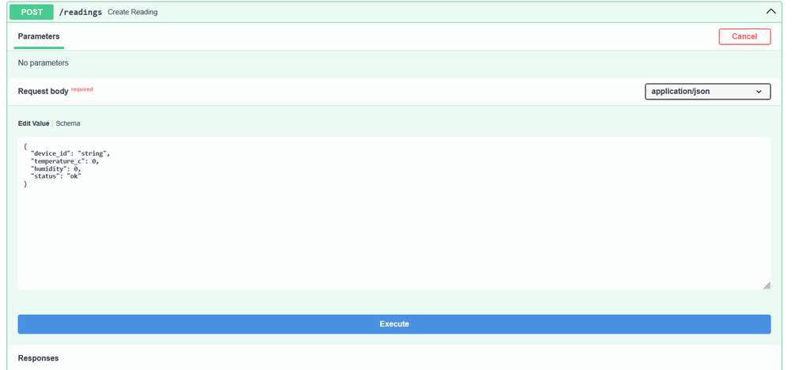

- upon pressing try it out, we can see and edit the request body and then press execute and see the response the endpoint gives. I will share a screenshot of the request body data and the response below:

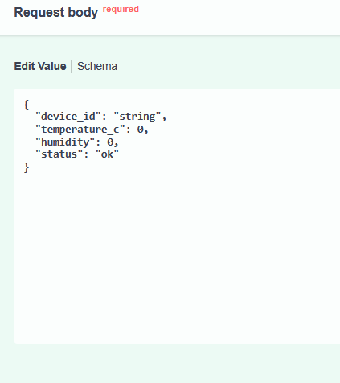

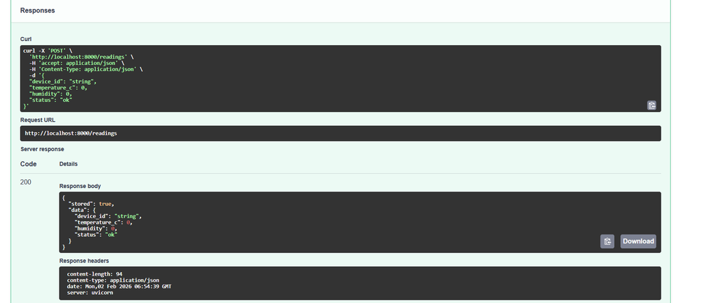

- you can see that we got a nice response, show both keys that we returned from our fastapi endpoint function create_readings. The frontend engineer can test the api and see the response body the fastapi endpoint will be giving from here and then destructure the response from the fetch/axios call accordingly
- lets now break a few things and see how the errors are shown:

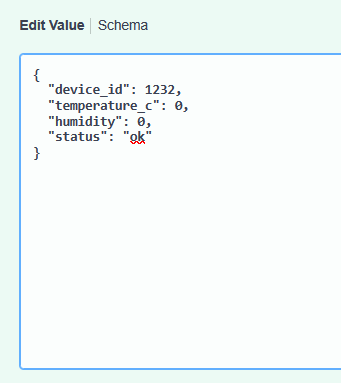

- I gave an int as the device_id even though the pydantic modal expects a string:

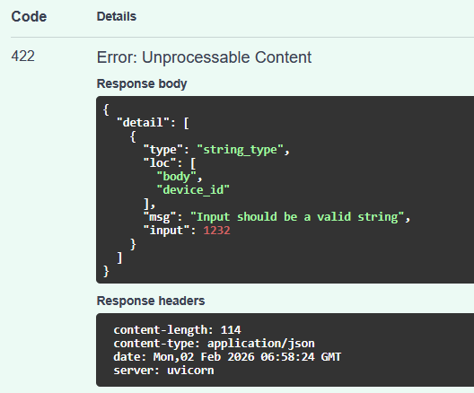

- as you can see, we get a nice error message saying input should be a valid string and an error code too. the frontend developer can access these error codes and messages and make try catch or if-else blocks using these of course.

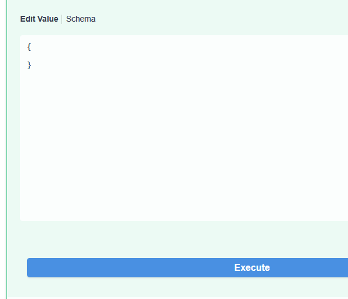

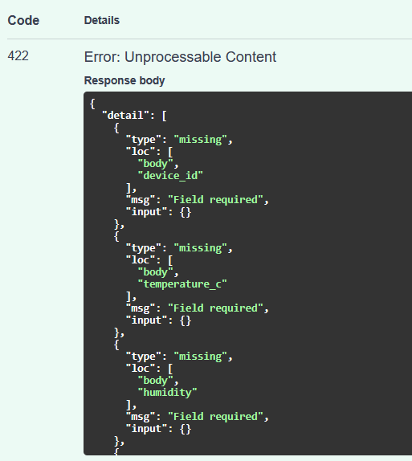

```python
from fastapi import FastAPI, HTTPException, status
from pydantic import BaseModel, Field
from typing import Literal

app = FastAPI()

class SensorReading(BaseModel):
    device_id: str = Field(min_length=3)
    temperature_c: float
    humidity: float
    status: Literal["ok", "warn", "error"]

# in-memory store (replace with real DB later)
readings_db: dict[int, SensorReading] = {}
next_id = 1

# put/update endpoint
@app.put("/readings/{reading_id}")
def update_reading(reading_id: int, payload: SensorReading):
    if reading_id not in readings_db:
        raise HTTPException(status_code=404, detail="reading not found")
    readings_db[reading_id] = payload
    return {"id": reading_id, "data": payload}

# delete endpoint
@app.delete("/readings/{reading_id}", status_code=status.HTTP_204_NO_CONTENT)
def delete_reading(reading_id: int):
    if reading_id not in readings_db:
        raise HTTPException(status_code=404, detail="reading not found")
    del readings_db[reading_id]
    return None
```

## Connecting a database with our backend layer

- We will obviously need to connect a database with our frontend+backend application. Lets say we use something simple like supabase. The setup would be very simple:
  - 1. we hit the command: uv add supabase
  - 2. we create our .env file and store our supabase url and supabase service key there which we get from our supabase project settings from the supabase website
  - 3. lastly we just create the supabase client and start working
  - this is what the code would look like somewhat:

```python
import os
from supabase import create_client, Client

SUPABASE_URL = os.getenv("SUPABASE_URL")
SUPABASE_SERVICE_KEY = os.getenv("SUPABASE_SERVICE_KEY")

supabase: Client = create_client(SUPABASE_URL, SUPABASE_SERVICE_KEY)

# Insert a row
def insert_reading(data: dict):
    return supabase.table("readings").insert(data).execute()

# Select rows
def list_readings():
    return supabase.table("readings").select("*").order("created_at", desc=True).execute()
```

- and after that we just make fastapi endpoint that wrap these supabase helper functions

```python
from fastapi import FastAPI, HTTPException
from pydantic import BaseModel

app = FastAPI()

class ReadingIn(BaseModel):
    device_id: str
    temperature_c: float
    humidity: float
    status: str

@app.post("/readings")
def create_reading(payload: ReadingIn):
    res = supabase.table("readings").insert(payload.model_dump()).execute()
    if not res.data:
        raise HTTPException(status_code=500, detail="Insert failed")
    return res.data[0]

@app.get("/readings")
def get_readings():
    res = supabase.table("readings").select("*").execute()
    return res.data
```

- a common confusion some people have at this point would be: "Why am I using FastAPI bro? I can just directly use the supabase library in typescript and I have my whole backend there"
- The answer can be given in several diff ways:
  - Secret keys: Any logic requiring a Supabase service key must stay on the server. Frontend code can only use anon keys.
  - IoT / ESP32: Devices should hit your backend, not your database directly. You validate, authenticate, and normalize payloads there.
  - Business logic: You often need custom rules, validation, and side‑effects (alerts, transforms, analytics) before storing data.
  - Rate limiting & security: Your API can block abuse, log requests, and apply stricter auth.
  - Data shaping: Backend can return exactly what frontend needs (joins, aggregations, caching).
  - Future flexibility: If you swap DBs or add services, frontend doesn’t change.

## CORs

```python
from fastapi import FastAPI
from fastapi.middleware.cors import CORSMiddleware

app = FastAPI()

# Allow your frontend URL(s)
origins = [
    "http://localhost:3000",
    "http://127.0.0.1:3000",
]

app.add_middleware(
    CORSMiddleware,
    allow_origins=origins,           # who can access
    allow_credentials=True,          # allow cookies/auth headers
    allow_methods=["*"],             # GET/POST/PUT/DELETE/etc
    allow_headers=["*"],             # headers like Authorization, Content-Type
)
```

- what we have done is introduce middleware into our fastapi backend, this middleware allows some origins (urls basically) to communicate with our fastapi endpoints, and rejects all other origins.
- next and react locally run on port 3000, if you are using vite then its on port 5173 I think (later, when we host our frontend on the web with a real domain, we will put that here). that is why i wrote the locahost:3000 url above.
- since we intend to work with esp, the following points are important:

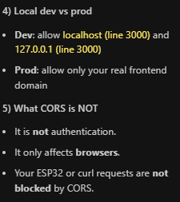